# Intrinsic growth results

mauricio

2/27/2021

# 1. Scenarios

We considered 3 arrangement for the quota baskets:  
- *Species with similar r:* we have a QB of low r and a group of high r.  
- *The normal r species predominates in a basket:* we have a QB were the “low r” species predominates (2 low r and 1 high r), and the other basket has the remaining species (1 low r and 1 high r).  
- *The high r species predominates in a basket:*we have a QB were the “high r” species predominates (1 low r and 2 high r), and the other basket has the remaining species (2 low r).

We are going to compare these arrangements in terms of biomass, efforts, ant total profits.

## 1.1 Parameters

| Species | r | K | Starting stock (X) | price |
| --- | --- | --- | --- | --- |
| 1 | 0.2 | 100 | 50 | 20 |
| 2 | 0.2 | 100 | 50 | 20 |
| 3 | 0.2 | 100 | 50 | 20 |
| 4 | 0.4 | 100 | 50 | 20 |
| 5 | 0.4 | 100 | 50 | 20 |

| Tech | q1 | q2 | q3 | q4 | q5 | cost |
| --- | --- | --- | --- | --- | --- | --- |
| 1 | 0.04 | 0.01 | 0.01 | 0.01 | 0.01 | 1 |
| 2 | 0.01 | 0.04 | 0.01 | 0.01 | 0.01 | 1 |
| 3 | 0.01 | 0.01 | 0.04 | 0.01 | 0.01 | 1 |
| 4 | 0.01 | 0.01 | 0.01 | 0.04 | 0.01 | 1 |
| 5 | 0.01 | 0.01 | 0.01 | 0.01 | 0.04 | 1 |

# 2. Biomass

## 2.1 Biomass per species

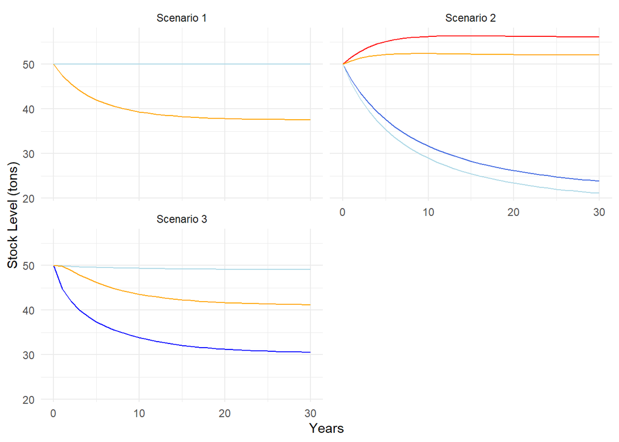

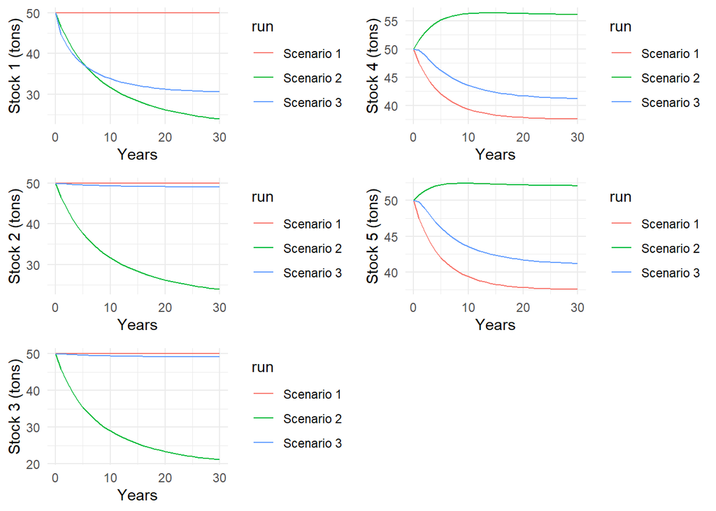

- The low r species display a stable stock when they are part of quota baskets without high r species.  
- The high r species display a descending stock when they are part of quota baskets without low r species.  
- The high r species have a more stable stock over time in basket dominated by low r species, however the stocks of the low r species are diminishing over time.

## 2.2 Total biomass in the ocean

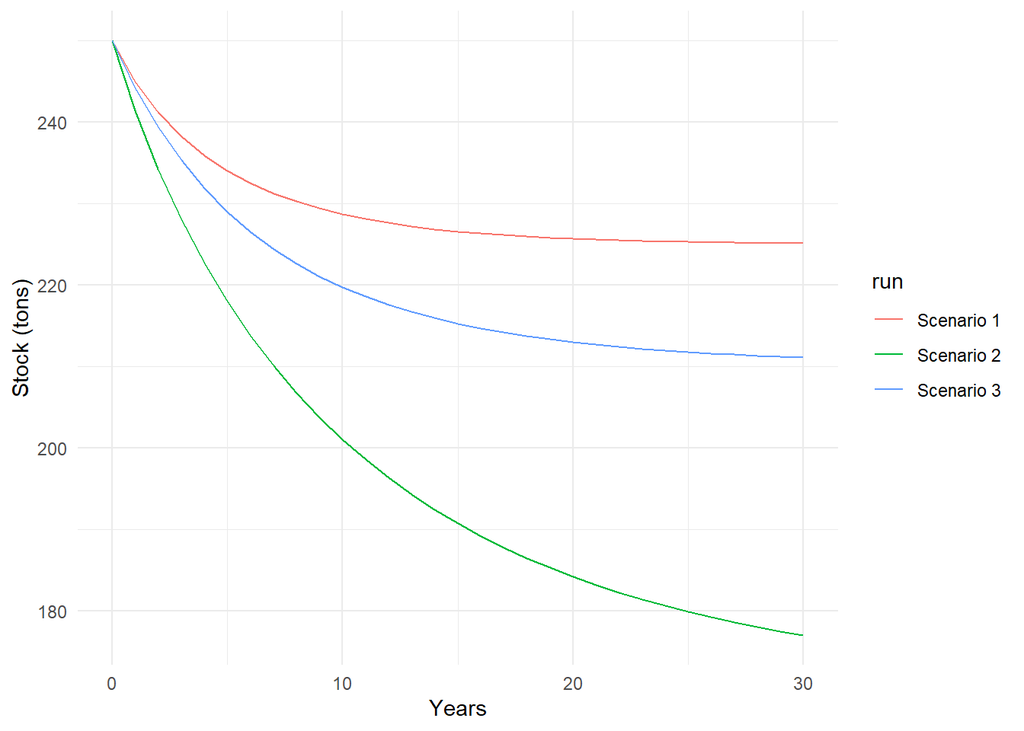

- Despite the better results for high r species, scenario 2 provides the worst results in stock.  
- Grouping species with similar r seems more reasonable to enjoy stable stocks over time.

# 3. Effort

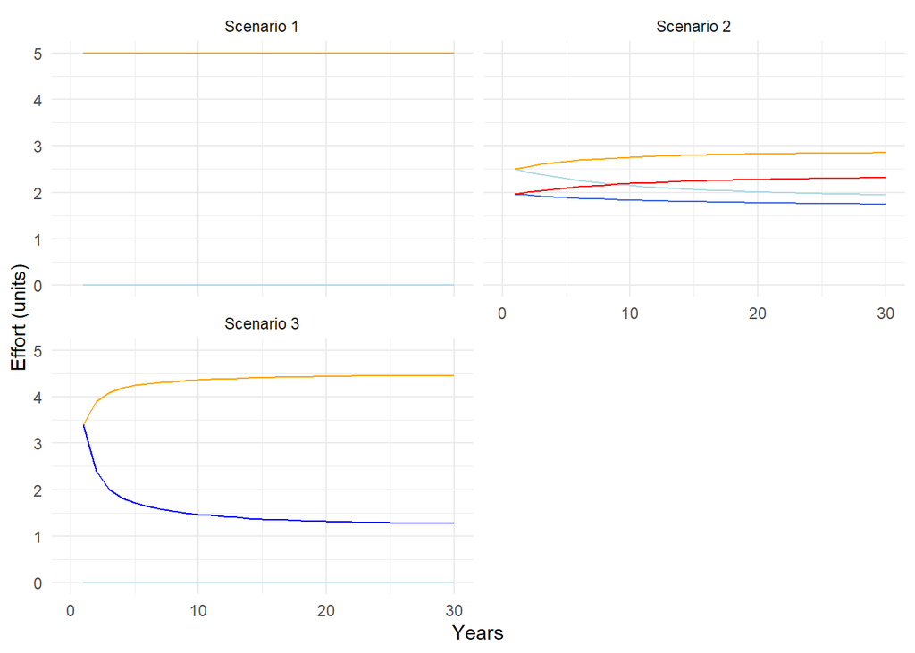

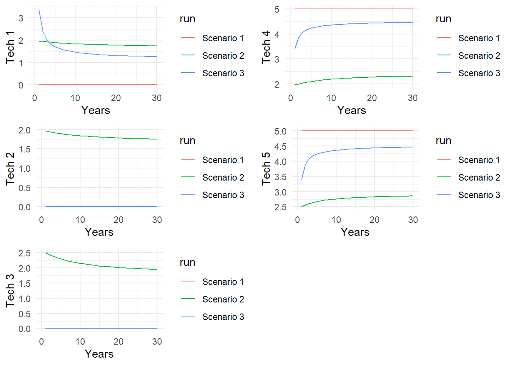

- In all the scenarios, the allocation favor the technologies that excel at harvesting high r species. The baskets dominated by high r species present **high mortality** (0.9).  
- Baskets with only low r species display low allocations (0 in many years) on the technologies that are good at catching them.

# 4. Profit

# 4.1 Profit per technology

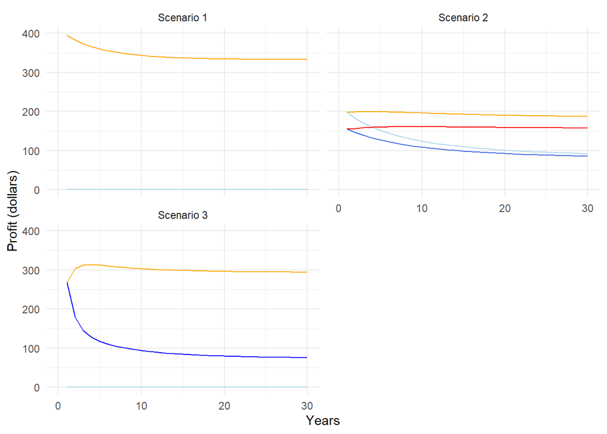

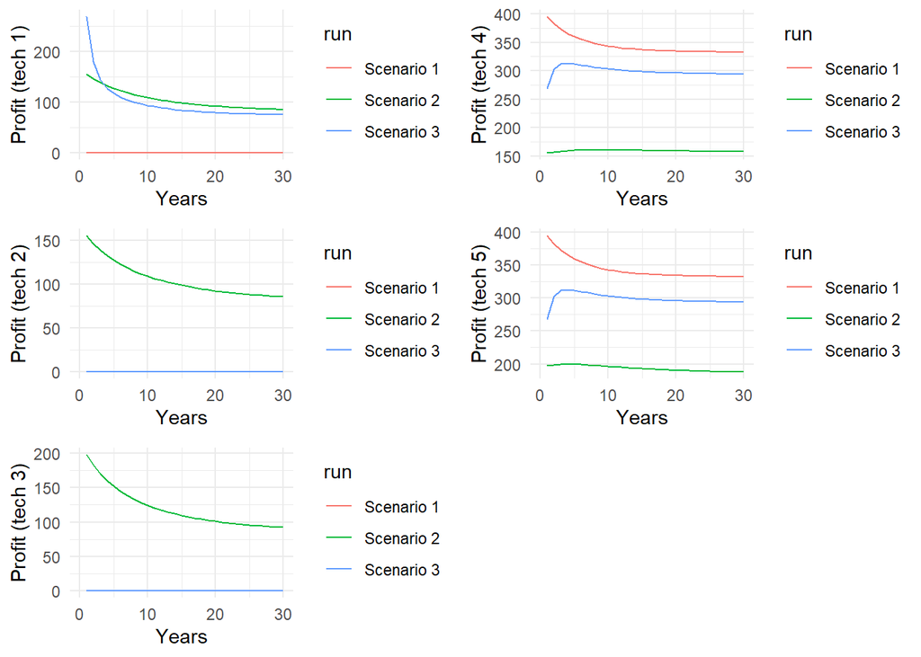

- The low or zero efforts allocated in baskets with only low r species have null(or almost zero) profits in their best technologies.  
- Profits are positive for the technologies good at catching high r species in all scenarios. The best results are for baskets dominated by high r species.

# 4.2 Total profit per scenario

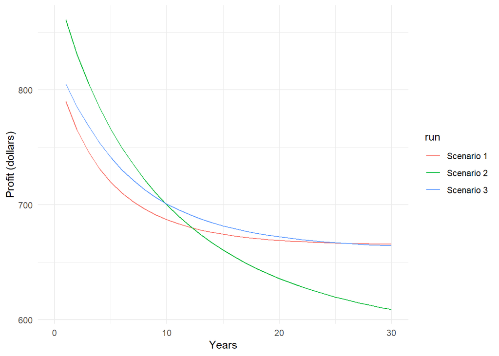

# 5. Summary

**Stocks**  
- The low r species display a stable stock when they are part of quota baskets without high r species.  
- The high r species display a descending stock when they are part of quota baskets without low r species.  
- The high r species have a more stable stock over time in basket dominated by low r species, however the stocks of the low r species are diminishing over time.  
- Despite the better results for high r species, scenario 2 provides the worst results in stock.  
- Grouping species with similar r seems more reasonable to enjoy stable stocks over time.

**Effort**  
- In all the scenarios, the allocation favor the technologies that excel at harvesting high r species. The baskets dominated by high r species present **high mortality** (0.9).  
- Baskets with only low r species display low allocations (0 in many years) on the technologies that are good at catching them.